# The rising price of energy and its impact on household cost of living

## Main points

(Note this document was prepared largely prior to the [Government announcement of plans to fix the price cap at an average of £2500 per year](https://www.bbc.co.uk/news/business-62831698) and reflects the changes expected under the planned changes to the Ofgem price cap which were due to take effect from 1 October 2022.)

## Gas Prices

The price of natural gas a risen sharply over the last 18 months. As Figure 1 shows, the average price of gas in the UK wholesale market have risen from 0.76 p/kWh, in the week leading to 28/08/2020, to 3.75 p/kWh for the same period of 2021, to 16.75 p/kWh for the same period of 2022.

According to the [BBC](https://www.bbc.co.uk/news/explainers-62644537) the resurgence of global economic activity in the recovery of the COVID-19 pandemic lead to a sharp increase in the demand of natural gas causing prices to rise. The geopolitical fallout of the Russian invasion of Ukraine in February 2022 exasperated this further (with Russia being the largest exported of gas in the world).

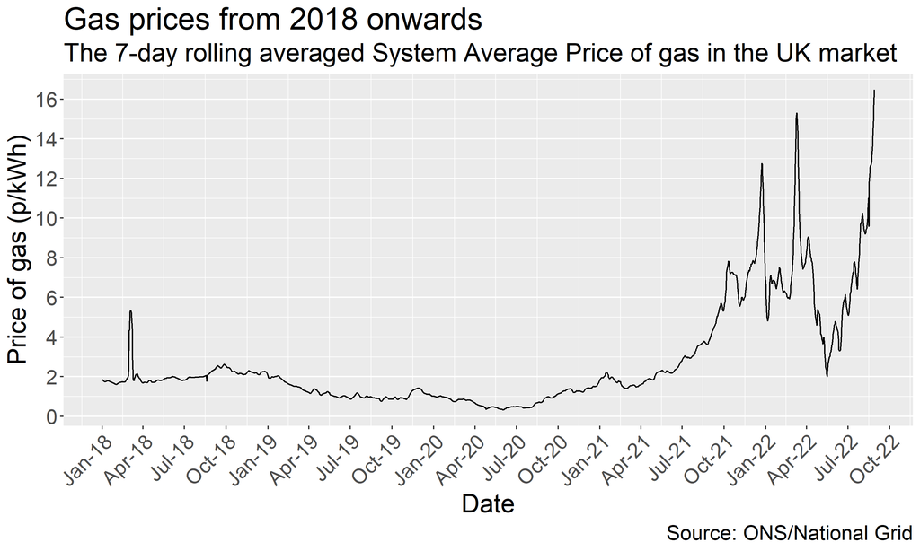

Figure 1: Wholesale market gas prices per unit from 2018 onward.

## Household Gas Prices

The price of gas (and electricity) that households pay is controlled the [Ofgem price cap](https://www.ofgem.gov.uk/information-consumers/energy-advice-households/check-if-energy-price-cap-affects-you). This sets an upper limit on the amount that energy suppliers are allowed to charge households per unit of fuel on their default tariffs. Since the surge in wholesale market prices of gas, the default tariffs charged by energy suppliers have broadly been these maximum permitted charge.

The current price cap, which has been in effect since 1 April 2022, fixes the price of gas at 7 p/kWh and electricity at 28 p/kWh. As can be seen in Figure 2, this has insulated households from the worst of the increase in market prices for the previous several months, when gas prices have averaged 7.5 p/kWh over the last six months, 12.2 p/kWh over the last month and, at the time of writing, are over 16 p/kWh.

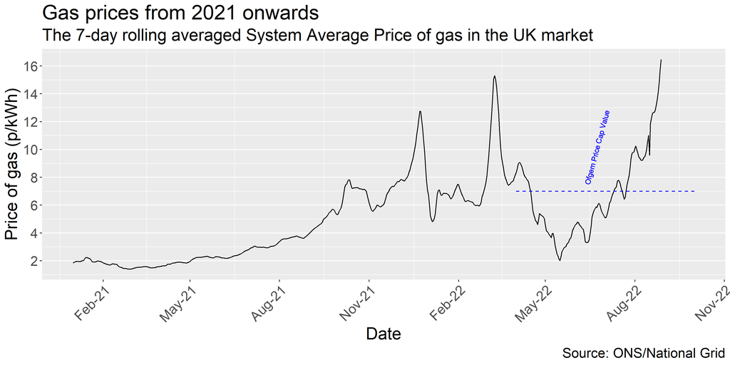

Figure 2: Wholesale market gas prices per unit from 2021 onward. The blue dashed line shows the Ofgem price cap that limits the maximum households can be charged for energy during the period from 1 April to 1 October 2022.

However, the price cap has been announced to be rising to 15 p/kWh for gas and 52 p/kWh from 1 October 2022. This marks a substantial increase of nearly 80% in the cost of household energy, from what is a comparatively high cost already (compared to the average market unit price of gas of 1.4 p/kWh in years 2018 to 2020).

## Inflation

The rising price of energy has been a key driver in the rise of inflation. In the UK, the official measure of price inflation is the Consumer Price Index with Housing (CPIH). This measures the change in price of common consumer goods and services. It weighs the relative impact of the price change of each product/service by the typical proportion of total expenditure spent on each product/service.

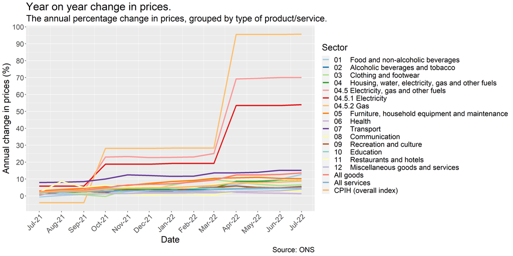

Figure 3: Annual percentage change in price by different categories of goods and services.

As Figure 3 shows, the typical annual percentage change in the prices of goods and services has been creeping up, with an overall annual inflation rate increase of 8.8% for July 2022. Breaking down by sectors this shows inflation is primarily driven by price changes in transport (with a 15.1% annual cost increase), food (with a 12.7% increase) and housing costs (which is includes household energy bills, with a 9.1% increase). The most stark increase however is visible when you plot the annual price changes for energy as separate goods/services. The price of household gas having increased by 96% in July 2022 from a year earlier.

According to the [ONS](https://www.ons.gov.uk/economy/inflationandpriceindices/bulletins/consumerpriceinflation/july2022) electricity, gas and other fuels contribute 1.87 percentage points to the current annual inflation rate. Should the 80% household energy price rise go ahead under the new Ofgem cap then a (simplistic) analysis suggests this could increase inflation by an additional 1.5%. The reason the rise of energy prices do not more strongly contribute to the inflation rate is that energy is currently weighted with less than three per cent of a typical consumer’s expenditure, reflecting spending habits from 2021 before prices soared.

## Household finances and energy costs

A study by ONS explored [family spending in the UK](https://www.ons.gov.uk/peoplepopulationandcommunity/personalandhouseholdfinances/expenditure/datasets/familyspendingworkbook1detailedexpenditureandtrends) up to March 2021. This showed that in the financial year ending 2021, the average household spent 4.8% of its expenditure on energy.

It also revealed this proportion is not uniform across income thresholds, but that lower income households spent a higher proportion of their income on energy. The lowest 10% of households by income spent on average 8.3% of their total expenditure on energy compared to 3.3% in the top 10% of households by income during this period.

A very simplistic analysis, taking the typical family household expenditure on energy in the financial year ending in 2021 and inflating this by the 70% price increase from July 2021 to July 2022 from the CPIH figures, and assuming a 5.1% increase in total household expenditure (inline with the [5.1% year-on-year three month average wage growth reported in June 2022](https://www.ons.gov.uk/employmentandlabourmarket/peopleinwork/earningsandworkinghours/timeseries/kac3/lms)), gives revised estimates of families currently spending on, average, 8.6% of their total expenditure on energy. For the lowest house income decile, this would be 14%, compared to 6% for the highest household income decile.

Assuming an additional rise in household energy spending of 80%, inline with the expected rise in Ofgem price cap prices, could mean from October 2022 average households may be spending on average 15% of their total expenditure on energy. For the lowest income decile households this could be an average as much as 25% of total expenditure, compared to 11% for the highest income decile households.

These estimates should be used with caution and are intended as illustrative rather than scientific. With that said, they represent a significant increase from the average of approximately 5% spent on energy during 2021. This should be particularly concerning when coupled with the general increase in prices for other goods and services that are expected as [businesses pass on their increased costs of energy](https://www.bbc.co.uk/news/business-62813782) (which are not protected by the Ofgem price cap) to consumers.

## Public opinion

The latest [Public opinions and social trends: household finances](https://www.ons.gov.uk/peoplepopulationandcommunity/wellbeing/datasets/publicopinionsandsocialtrendsgreatbritainhouseholdfinances) data (covering 17 to 29 August 2022) show the vast majority of the general public have concerns with rising cost of living.

91% of responds said their cost of living had increased, of which 79% reported their gas or electricity bills had increased. While this is less than the 96% of respondents who reported the price of their food bill had increased, when asked which price increase that were most worried about, the majority (62%) responded with the energy. This is compared to 18 per cent who said food price increases concerned them the most.

The full table is presented below in Table 1.

Table 1: Table of responses to opinion surveys on cost of living

| Survey question and response options | All persons % | Aged 16 to 29 % | Aged 30 to 49 % | Aged 50 to 69 % | Aged 70 and over % | Men % | Women % |
| --- | --- | --- | --- | --- | --- | --- | --- |
| Over the last month, has your cost of living changed? |  |  |  |  |  |  |  |
| My cost of living has increased | 91 | 84 | 92 | 92 | 93 | 89 | 92 |
| My cost of living has stayed the same | 9 | 15 | 7 | 7 | 7 | 11 | 7 |
| My cost of living has decreased | 1 | 1 | [c] | 1 | [c] | <1 | 1 |
| Among those who said "My cost of living has increased": |  |  |  |  |  |  |  |
| Over the last month, for what reasons has your cost of living increased? [note 2] |  |  |  |  |  |  |  |
| My gas or electricity bills have increased | 79 | 65 | 84 | 81 | 78 | 78 | 79 |
| My rent or mortgage costs have increased | 17 | 26 | 19 | 16 | 5 | 15 | 19 |
| The price of my food shop has increased | 96 | 93 | 97 | 96 | 97 | 96 | 96 |
| The price of my fuel has increased | 71 | 61 | 71 | 75 | 73 | 72 | 70 |
| The price of my public transport has increased | 13 | 27 | 15 | 9 | 4 | 11 | 15 |
| Other | 8 | 8 | 9 | 7 | 6 | 6 | 9 |
| Among those who said "My cost of living has increased" and answered "Over the last month, for what reasons has your cost of living increased?": |  |  |  |  |  |  |  |
| Of these, which are you most worried about? |  |  |  |  |  |  |  |
| My gas or electricity bills have increased | 62 | 52 | 64 | 64 | 62 | 62 | 61 |
| My rent or mortgage costs have increased | 2 | 7 | 2 | 1 | 1 | 2 | 2 |
| The price of my food shop has increased | 18 | 17 | 19 | 17 | 17 | 16 | 20 |
| The price of my fuel has increased | 10 | 16 | 8 | 10 | 7 | 10 | 9 |
| The price of my public transport has increased | <1 | [c] | [c] | [c] | [c] | [c] | 1 |
| Other | <1 | [c] | [c] | [c] | [c] | [c] | <1 |
| I am not worried about any of these | 8 | 5 | 7 | 8 | 13 | 9 | 7 |

## Recommendations

Gas prices are still very volatile and are expected to rise further - due to the usual seasonal increase in global demand during the cooler months of October to March in the northern hemisphere, as well as continuing geopolitical events such as the [closure of the Nord Stream 1 gas pipeline](https://www.bbc.co.uk/news/world-europe-60131520).

In order to reduce the harm to household finances further, additional intervention in controlling household energy bills is suggested. This could take the form of freezing the energy price cap at a level lower than the planned October 2022 Ofgem cap level. This would help reduce the projected impacts to inflation and household expenditure outlined above.

However, even with this in place, additional targeted support for lower income households may be needed to address the disproportionate impact that households of different incomes are already facing.